# This HW has the following requirements.

- Rename this Jupyter Notebook as yourlastname_firstinitial_HW_Superstoresales_s,ipynb
- Import SuperstoreSales.xlsx
- You should **user multiple tables/charts to answer each question**. Make sure to demonstrate your skills in both data transformation and data visualization.
- You can and should **use multiple cells (more than one) to answer each question**.
- But, do not stop here! **For each question, you need to interpret the table(s) and chart(s) and provide a short summary of the results from table/chart. Include your interpretations of the tables/charts in Markdown dells right below tables/charts. Use bullets and/or numbers**.

Be creative! Be a good storyteller!

Note: Some questions are adapted from Teradatauniversitynetwork. Source of data: Tableau.com

```python
import pandas as pd
import numpy as np

%matplotlib inline
import matplotlib.pyplot as plt

import seaborn as sns

from scipy import stats

pd.set_option('display.max_columns', 500)
```

## Connect to the Data

```python
df = pd.read_excel("data/SuperstoreSales.xlsx")
df.head()
```

|  | Order ID | Order Date | Order Priority | Order Quantity | Sales | Discount | Ship Mode | Profit | Unit Price | Shipping Cost | Customer Name | Customer State | Zip Code | Region | Customer Segment | Product Category | Product Sub-Category | Product Name | Product Container | Product Base Margin | Ship Date |
| --- | --- | --- | --- | --- | --- | --- | --- | --- | --- | --- | --- | --- | --- | --- | --- | --- | --- | --- | --- | --- | --- |
| 0 | 3 | 2010-08-26 | Low | 6 | 261.5400 | 0.04 | Regular Air | -213.250 | 38.94 | 35.00 | Muhammed MacIntyre | New Jersey | 7514 | East | Small Business | Office Supplies | Storage & Organization | Eldon Base for stackable storage shelf, platinum | Large Box | 0.80 | 2010-09-02 |
| 1 | 6 | 2012-01-03 | Not Specified | 2 | 6.9300 | 0.01 | Regular Air | -4.640 | 2.08 | 2.56 | Ruben Dartt | New York | 10457 | East | Corporate | Office Supplies | Scissors, Rulers and Trimmers | Kleencut® Forged Office Shears by Acme United ... | Small Pack | 0.55 | 2012-01-04 |
| 2 | 32 | 2011-05-28 | High | 15 | 140.5600 | 0.04 | Regular Air | -128.380 | 8.46 | 8.99 | Liz Pelletier | Ohio | 44197 | Central | Corporate | Technology | Computer Peripherals | Imation 3.5 IBM Diskettes, 10/Box | Small Pack | 0.79 | 2011-05-29 |
| 3 | 32 | 2011-05-28 | High | 24 | 1761.4000 | 0.09 | Delivery Truck | -1748.560 | 70.89 | 89.30 | Liz Pelletier | Ohio | 44197 | Central | Corporate | Furniture | Tables | KI Conference Tables | Jumbo Box | 0.72 | 2011-05-29 |
| 4 | 32 | 2011-05-28 | High | 23 | 160.2335 | 0.04 | Regular Air | -85.129 | 7.99 | 5.03 | Liz Pelletier | Ohio | 44197 | Central | Corporate | Technology | Telephones and Communication | Bell Sonecor JB700 Caller ID | Medium Box | 0.60 | 2011-05-30 |

```python
# check column names, number of observations, data type
df.info()
```

```
<class 'pandas.core.frame.DataFrame'>
RangeIndex: 8399 entries, 0 to 8398
Data columns (total 21 columns):
 #   Column                Non-Null Count  Dtype
---  ------                --------------  -----
 0   Order ID              8399 non-null   int64
 1   Order Date            8399 non-null   datetime64[ns]
 2   Order Priority        8399 non-null   object
 3   Order Quantity        8399 non-null   int64
 4   Sales                 8399 non-null   float64
 5   Discount              8399 non-null   float64
 6   Ship Mode             8399 non-null   object
 7   Profit                8399 non-null   float64
 8   Unit Price            8399 non-null   float64
 9   Shipping Cost         8399 non-null   float64
 10  Customer Name         8399 non-null   object
 11  Customer State        8399 non-null   object
 12  Zip Code              8399 non-null   int64
 13  Region                8399 non-null   object
 14  Customer Segment      8399 non-null   object
 15  Product Category      8399 non-null   object
 16  Product Sub-Category  8399 non-null   object
 17  Product Name          8399 non-null   object
 18  Product Container     8399 non-null   object
 19  Product Base Margin   8399 non-null   float64
 20  Ship Date             8399 non-null   datetime64[ns]
dtypes: datetime64[ns](2), float64(6), int64(3), object(10)
memory usage: 1.3+ MB
```

```python
df.describe()
```

|  | Order ID | Order Quantity | Sales | Discount | Profit | Unit Price | Shipping Cost | Zip Code | Product Base Margin |
| --- | --- | --- | --- | --- | --- | --- | --- | --- | --- |
| count | 8399.000000 | 8399.000000 | 8399.000000 | 8399.000000 | 8399.000000 | 8399.000000 | 8399.000000 | 8399.000000 | 8399.000000 |
| mean | 29965.179783 | 25.575426 | 1774.860490 | 0.049664 | 181.401194 | 89.310426 | 12.856427 | 48256.097631 | 0.512886 |
| std | 17260.883447 | 14.482837 | 3585.107345 | 0.031826 | 1224.670845 | 290.361311 | 17.318257 | 30689.098271 | 0.135991 |
| min | 3.000000 | 1.000000 | 2.240000 | 0.000000 | -16253.680000 | 0.990000 | 0.490000 | 501.000000 | 0.350000 |
| 25% | 15011.500000 | 13.000000 | 143.035000 | 0.020000 | -82.764250 | 6.480000 | 3.300000 | 21794.000000 | 0.380000 |
| 50% | 29857.000000 | 26.000000 | 449.420000 | 0.050000 | -1.490000 | 20.990000 | 6.070000 | 43317.000000 | 0.520000 |
| 75% | 44596.000000 | 38.000000 | 1706.285000 | 0.080000 | 166.712250 | 85.990000 | 13.990000 | 81221.000000 | 0.590000 |
| max | 59973.000000 | 50.000000 | 89061.050000 | 0.250000 | 27220.690000 | 6783.020000 | 164.730000 | 99403.000000 | 0.850000 |

## Rename column names

- Remove extra spaces
- Lowercase names

```python
df.columns = df.columns.str.replace(' ', '')
df.columns = df.columns.str.lower()
df.columns
```

```
Index(['orderid', 'orderdate', 'orderpriority', 'orderquantity', 'sales',
       'discount', 'shipmode', 'profit', 'unitprice', 'shippingcost',
       'customername', 'customerstate', 'zipcode', 'region', 'customersegment',
       'productcategory', 'productsub-category', 'productname',
       'productcontainer', 'productbasemargin', 'shipdate'],
      dtype='object')
```

## Inspect data

```python
# check missing values
df.isna().sum()
```

```
orderid                0
orderdate              0
orderpriority          0
orderquantity          0
sales                  0
discount               0
shipmode               0
profit                 0
unitprice              0
shippingcost           0
customername           0
customerstate          0
zipcode                0
region                 0
customersegment        0
productcategory        0
productsub-category    0
productname            0
productcontainer       0
productbasemargin      0
shipdate               0
dtype: int64
```

```python
# summary statistics
df.describe()
```

|  | orderid | orderquantity | sales | discount | profit | unitprice | shippingcost | zipcode | productbasemargin |
| --- | --- | --- | --- | --- | --- | --- | --- | --- | --- |
| count | 8399.000000 | 8399.000000 | 8399.000000 | 8399.000000 | 8399.000000 | 8399.000000 | 8399.000000 | 8399.000000 | 8399.000000 |
| mean | 29965.179783 | 25.575426 | 1774.860490 | 0.049664 | 181.401194 | 89.310426 | 12.856427 | 48256.097631 | 0.512886 |
| std | 17260.883447 | 14.482837 | 3585.107345 | 0.031826 | 1224.670845 | 290.361311 | 17.318257 | 30689.098271 | 0.135991 |
| min | 3.000000 | 1.000000 | 2.240000 | 0.000000 | -16253.680000 | 0.990000 | 0.490000 | 501.000000 | 0.350000 |
| 25% | 15011.500000 | 13.000000 | 143.035000 | 0.020000 | -82.764250 | 6.480000 | 3.300000 | 21794.000000 | 0.380000 |
| 50% | 29857.000000 | 26.000000 | 449.420000 | 0.050000 | -1.490000 | 20.990000 | 6.070000 | 43317.000000 | 0.520000 |
| 75% | 44596.000000 | 38.000000 | 1706.285000 | 0.080000 | 166.712250 | 85.990000 | 13.990000 | 81221.000000 | 0.590000 |
| max | 59973.000000 | 50.000000 | 89061.050000 | 0.250000 | 27220.690000 | 6783.020000 | 164.730000 | 99403.000000 | 0.850000 |

## Indexing

```python
# index is like primary key in database (unique number assigned to each observation)
# check index column
df.index
```

```
RangeIndex(start=0, stop=8399, step=1)
```

```python
# then set datetime [date] column as index (primary key). This is for time series analysis below.
# orderdate
df = df.set_index('orderdate')
df.head()
```

| orderdate | orderid | orderpriority | orderquantity | sales | discount | shipmode | profit | unitprice | shippingcost | customername | customerstate | zipcode | region | customersegment | productcategory | productsub-category | productname | productcontainer | productbasemargin | shipdate |
| --- | --- | --- | --- | --- | --- | --- | --- | --- | --- | --- | --- | --- | --- | --- | --- | --- | --- | --- | --- | --- |
| 2010-08-26 | 3 | Low | 6 | 261.5400 | 0.04 | Regular Air | -213.250 | 38.94 | 35.00 | Muhammed MacIntyre | New Jersey | 7514 | East | Small Business | Office Supplies | Storage & Organization | Eldon Base for stackable storage shelf, platinum | Large Box | 0.80 | 2010-09-02 |
| 2012-01-03 | 6 | Not Specified | 2 | 6.9300 | 0.01 | Regular Air | -4.640 | 2.08 | 2.56 | Ruben Dartt | New York | 10457 | East | Corporate | Office Supplies | Scissors, Rulers and Trimmers | Kleencut® Forged Office Shears by Acme United ... | Small Pack | 0.55 | 2012-01-04 |
| 2011-05-28 | 32 | High | 15 | 140.5600 | 0.04 | Regular Air | -128.380 | 8.46 | 8.99 | Liz Pelletier | Ohio | 44197 | Central | Corporate | Technology | Computer Peripherals | Imation 3.5 IBM Diskettes, 10/Box | Small Pack | 0.79 | 2011-05-29 |
| 2011-05-28 | 32 | High | 24 | 1761.4000 | 0.09 | Delivery Truck | -1748.560 | 70.89 | 89.30 | Liz Pelletier | Ohio | 44197 | Central | Corporate | Furniture | Tables | KI Conference Tables | Jumbo Box | 0.72 | 2011-05-29 |
| 2011-05-28 | 32 | High | 23 | 160.2335 | 0.04 | Regular Air | -85.129 | 7.99 | 5.03 | Liz Pelletier | Ohio | 44197 | Central | Corporate | Technology | Telephones and Communication | Bell Sonecor JB700 Caller ID | Medium Box | 0.60 | 2011-05-30 |

## Summary Questions

### What is the total sales (sum())?

```python
df["sales"].sum()
```

```
14907053.254
```

### What is the total profit?

```python
df['profit'].sum()
```

```
1523588.6295
```

## Time series (seasonality)

### Do you observe any seasonality in the sales volume?

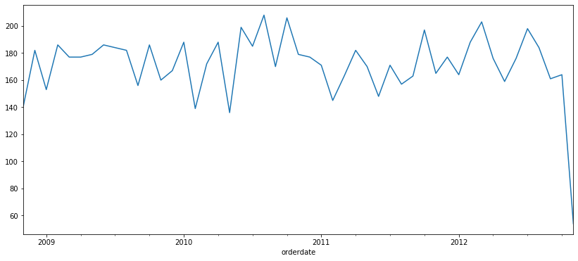

```python
plt.figure(figsize=[14,6])
df.resample('M').size().plot()
```

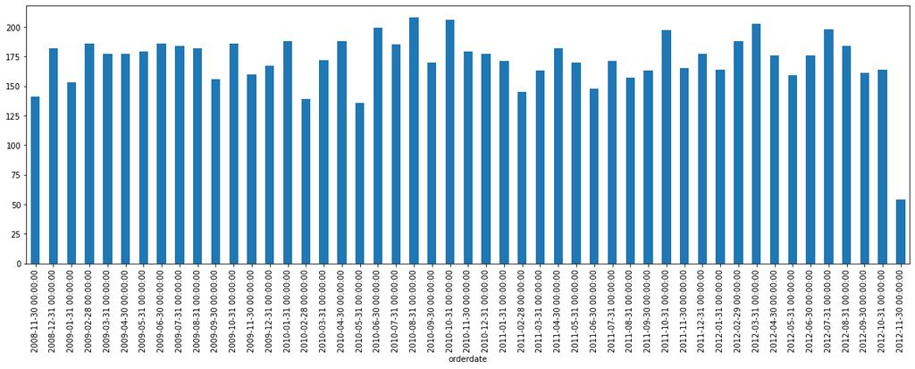

```python
plt.figure(figsize=[20,6])
df.resample('M').size().plot(kind='bar')
```

### Do you observe any seasonality in the shipping cost?

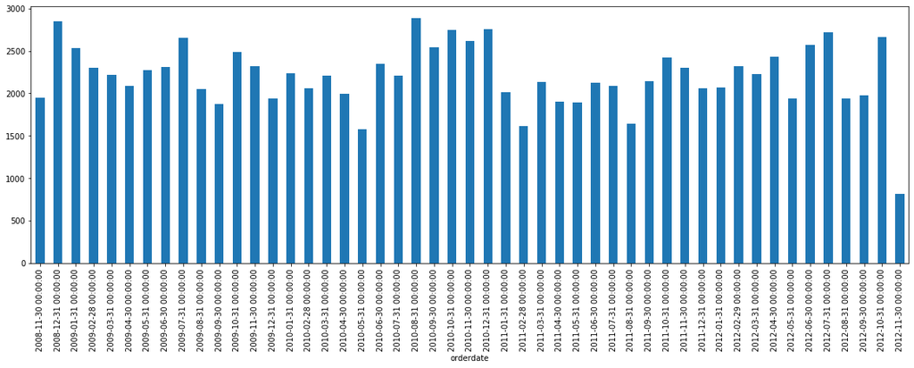

```python
plt.figure(figsize=[20,6])
df.resample('M')["shippingcost"].sum().plot(kind='bar')
```

There appears to be some relationship between shipping cost and the month

## Detailed Questions

### What is the sales total in each product category? Which product category is doing well?

```python
df.groupby("productcategory")["sales"].sum().sort_values()
```

```
productcategory
Office Supplies    3800227.370
Furniture          5119254.482
Technology         5987571.402
Name: sales, dtype: float64
```

The technology category is doing the best, with 5,987,571.402 total in sales

### What are top two categories in terms of profit?

```python
df.groupby("productcategory")["profit"].sum().sort_values(ascending=False).head(2)
```

```
productcategory
Technology         855437.2250
Office Supplies    515776.6045
Name: profit, dtype: float64
```

Technology and office supplies are the highest categories in terms of profit

### Which region is profitable compared to other regions? Any region experiencing financial losses? (Include productcategory in this analysis)

```python
df.columns
```

```
Index(['orderid', 'orderpriority', 'orderquantity', 'sales', 'discount',
       'shipmode', 'profit', 'unitprice', 'shippingcost', 'customername',
       'customerstate', 'zipcode', 'region', 'customersegment',
       'productcategory', 'productsub-category', 'productname',
       'productcontainer', 'productbasemargin', 'shipdate'],
      dtype='object')
```

```python
df.groupby(["region", "productcategory"])["profit"].sum().sort_values(ascending=False)
```

```
region   productcategory
South    Technology         302117.5900
West     Technology         219514.0210
East     Technology         203053.3850
West     Office Supplies    145669.4595
South    Office Supplies    140659.2615
Central  Technology         130752.2290
         Office Supplies    121977.2900
East     Office Supplies    107470.5935
South    Furniture           62901.9000
West     Furniture           57684.6700
Central  Furniture           44509.6900
East     Furniture          -12721.4600
Name: profit, dtype: float64
```

```python
df.pivot_table(index="region", columns="productcategory", values="profit", aggfunc="sum", fill_value=0, margins=True)
```

| productcategory region | Furniture | Office Supplies | Technology | All |
| --- | --- | --- | --- | --- |
| Central | 44509.69 | 121977.2900 | 130752.229 | 2.972392e+05 |
| East | -12721.46 | 107470.5935 | 203053.385 | 2.978025e+05 |
| South | 62901.90 | 140659.2615 | 302117.590 | 5.056788e+05 |
| West | 57684.67 | 145669.4595 | 219514.021 | 4.228682e+05 |
| All | 152374.80 | 515776.6045 | 855437.225 | 1.523589e+06 |

Looks like the East region is having a deficit with their Furniture products. Overall, the South region has the most profit, with about 500k in profit total and 300k in their technology category.

### Which state in the East is least profitable? Include Product Category in your analysis.

```python
df.head()
```

| orderdate | orderid | orderpriority | orderquantity | sales | discount | shipmode | profit | unitprice | shippingcost | customername | customerstate | zipcode | region | customersegment | productcategory | productsub-category | productname | productcontainer | productbasemargin | shipdate |
| --- | --- | --- | --- | --- | --- | --- | --- | --- | --- | --- | --- | --- | --- | --- | --- | --- | --- | --- | --- | --- |
| 2010-08-26 | 3 | Low | 6 | 261.5400 | 0.04 | Regular Air | -213.250 | 38.94 | 35.00 | Muhammed MacIntyre | New Jersey | 7514 | East | Small Business | Office Supplies | Storage & Organization | Eldon Base for stackable storage shelf, platinum | Large Box | 0.80 | 2010-09-02 |
| 2012-01-03 | 6 | Not Specified | 2 | 6.9300 | 0.01 | Regular Air | -4.640 | 2.08 | 2.56 | Ruben Dartt | New York | 10457 | East | Corporate | Office Supplies | Scissors, Rulers and Trimmers | Kleencut® Forged Office Shears by Acme United ... | Small Pack | 0.55 | 2012-01-04 |
| 2011-05-28 | 32 | High | 15 | 140.5600 | 0.04 | Regular Air | -128.380 | 8.46 | 8.99 | Liz Pelletier | Ohio | 44197 | Central | Corporate | Technology | Computer Peripherals | Imation 3.5 IBM Diskettes, 10/Box | Small Pack | 0.79 | 2011-05-29 |
| 2011-05-28 | 32 | High | 24 | 1761.4000 | 0.09 | Delivery Truck | -1748.560 | 70.89 | 89.30 | Liz Pelletier | Ohio | 44197 | Central | Corporate | Furniture | Tables | KI Conference Tables | Jumbo Box | 0.72 | 2011-05-29 |
| 2011-05-28 | 32 | High | 23 | 160.2335 | 0.04 | Regular Air | -85.129 | 7.99 | 5.03 | Liz Pelletier | Ohio | 44197 | Central | Corporate | Technology | Telephones and Communication | Bell Sonecor JB700 Caller ID | Medium Box | 0.60 | 2011-05-30 |

```python
df[df["region"] == "East"].groupby(["customerstate", "productcategory"])["profit"].sum().sort_values(ascending=False)
```

```
customerstate  productcategory
New York       Technology         63511.4390
Mass           Office Supplies    41313.6870
New Jersey     Technology         39667.9600
Connecticut    Technology         36178.5660
Mass           Technology         33954.6770
Delaware       Technology         29740.7430
New York       Office Supplies    25573.0065
               Furniture          23014.8100
Connecticut    Office Supplies    20425.2045
New Jersey     Office Supplies    14495.9140
Delaware       Office Supplies     5662.7815
               Furniture            938.9900
Mass           Furniture          -5651.1800
Connecticut    Furniture         -12852.1300
New Jersey     Furniture         -18171.9500
Name: profit, dtype: float64
```

```python
df[df["region"] == "East"].pivot_table(index="customerstate", columns="productcategory", values="profit", aggfunc="sum", fill_value=0, margins=True)
```

| productcategory customerstate | Furniture | Office Supplies | Technology | All |
| --- | --- | --- | --- | --- |
| Connecticut | -12852.13 | 20425.2045 | 36178.566 | 43751.6405 |
| Delaware | 938.99 | 5662.7815 | 29740.743 | 36342.5145 |
| Mass | -5651.18 | 41313.6870 | 33954.677 | 69617.1840 |
| New Jersey | -18171.95 | 14495.9140 | 39667.960 | 35991.9240 |
| New York | 23014.81 | 25573.0065 | 63511.439 | 112099.2555 |
| All | -12721.46 | 107470.5935 | 203053.385 | 297802.5185 |

The least profitable state is New Jersey as they have 18k of deficit in Furniture and an overall profit of 36k

### Nebraska

```python
df.columns
```

```
Index(['orderid', 'orderpriority', 'orderquantity', 'sales', 'discount',
       'shipmode', 'profit', 'unitprice', 'shippingcost', 'customername',
       'customerstate', 'zipcode', 'region', 'customersegment',
       'productcategory', 'productsub-category', 'productname',
       'productcontainer', 'productbasemargin', 'shipdate'],
      dtype='object')
```

```python
plt.figure(figsize=[20,6])
df[df["customerstate"] == "Nebraska"].resample('Y')["profit"].sum()
```

```
orderdate
2008-12-31     -363.9200
2009-12-31    18355.1030
2010-12-31    12314.2330
2011-12-31    12363.0425
2012-12-31    15597.6875
Freq: A-DEC, Name: profit, dtype: float64
```

2008 was the worst year for Nebraska, with a deficit of 363

#### Which part of Nebraska is profitable?

```python
df.head()
```

| orderdate | orderid | orderpriority | orderquantity | sales | discount | shipmode | profit | unitprice | shippingcost | customername | customerstate | zipcode | region | customersegment | productcategory | productsub-category | productname | productcontainer | productbasemargin | shipdate |
| --- | --- | --- | --- | --- | --- | --- | --- | --- | --- | --- | --- | --- | --- | --- | --- | --- | --- | --- | --- | --- |
| 2010-08-26 | 3 | Low | 6 | 261.5400 | 0.04 | Regular Air | -213.250 | 38.94 | 35.00 | Muhammed MacIntyre | New Jersey | 7514 | East | Small Business | Office Supplies | Storage & Organization | Eldon Base for stackable storage shelf, platinum | Large Box | 0.80 | 2010-09-02 |
| 2012-01-03 | 6 | Not Specified | 2 | 6.9300 | 0.01 | Regular Air | -4.640 | 2.08 | 2.56 | Ruben Dartt | New York | 10457 | East | Corporate | Office Supplies | Scissors, Rulers and Trimmers | Kleencut® Forged Office Shears by Acme United ... | Small Pack | 0.55 | 2012-01-04 |
| 2011-05-28 | 32 | High | 15 | 140.5600 | 0.04 | Regular Air | -128.380 | 8.46 | 8.99 | Liz Pelletier | Ohio | 44197 | Central | Corporate | Technology | Computer Peripherals | Imation 3.5 IBM Diskettes, 10/Box | Small Pack | 0.79 | 2011-05-29 |
| 2011-05-28 | 32 | High | 24 | 1761.4000 | 0.09 | Delivery Truck | -1748.560 | 70.89 | 89.30 | Liz Pelletier | Ohio | 44197 | Central | Corporate | Furniture | Tables | KI Conference Tables | Jumbo Box | 0.72 | 2011-05-29 |
| 2011-05-28 | 32 | High | 23 | 160.2335 | 0.04 | Regular Air | -85.129 | 7.99 | 5.03 | Liz Pelletier | Ohio | 44197 | Central | Corporate | Technology | Telephones and Communication | Bell Sonecor JB700 Caller ID | Medium Box | 0.60 | 2011-05-30 |

```python
df[df["customerstate"] == "Nebraska"].groupby("zipcode")["profit"].sum().sort_values(ascending=False)
```

```
zipcode
68770    19498.4820
68717    12265.1240
69367    10809.8590
68001     7771.4990
68155     7049.8825
69141     1302.5270
69358      185.5075
68016     -616.7350
Name: profit, dtype: float64
```

There was 19498 profit total in the zipcode 68770

### Overall, what kinds of furniture are not profitable?

```python
df[df["productcategory"] == "Furniture"].groupby("productsub-category")["profit"].sum().sort_values()
```

```
productsub-category
Tables                -61271.15
Bookcases             -33170.68
Office Furnishings     96878.40
Chairs & Chairmats    149938.23
Name: profit, dtype: float64
```

The subcategories for Furniture which give negative profit are tables and bookcases

### Overall, what kinds of office supplies are most profitable? What kinds of office supplies need to be improved in terms of sales and profits?

```python
df.head()
```

| orderdate | orderid | orderpriority | orderquantity | sales | discount | shipmode | profit | unitprice | shippingcost | customername | customerstate | zipcode | region | customersegment | productcategory | productsub-category | productname | productcontainer | productbasemargin | shipdate |
| --- | --- | --- | --- | --- | --- | --- | --- | --- | --- | --- | --- | --- | --- | --- | --- | --- | --- | --- | --- | --- |
| 2010-08-26 | 3 | Low | 6 | 261.5400 | 0.04 | Regular Air | -213.250 | 38.94 | 35.00 | Muhammed MacIntyre | New Jersey | 7514 | East | Small Business | Office Supplies | Storage & Organization | Eldon Base for stackable storage shelf, platinum | Large Box | 0.80 | 2010-09-02 |
| 2012-01-03 | 6 | Not Specified | 2 | 6.9300 | 0.01 | Regular Air | -4.640 | 2.08 | 2.56 | Ruben Dartt | New York | 10457 | East | Corporate | Office Supplies | Scissors, Rulers and Trimmers | Kleencut® Forged Office Shears by Acme United ... | Small Pack | 0.55 | 2012-01-04 |
| 2011-05-28 | 32 | High | 15 | 140.5600 | 0.04 | Regular Air | -128.380 | 8.46 | 8.99 | Liz Pelletier | Ohio | 44197 | Central | Corporate | Technology | Computer Peripherals | Imation 3.5 IBM Diskettes, 10/Box | Small Pack | 0.79 | 2011-05-29 |
| 2011-05-28 | 32 | High | 24 | 1761.4000 | 0.09 | Delivery Truck | -1748.560 | 70.89 | 89.30 | Liz Pelletier | Ohio | 44197 | Central | Corporate | Furniture | Tables | KI Conference Tables | Jumbo Box | 0.72 | 2011-05-29 |
| 2011-05-28 | 32 | High | 23 | 160.2335 | 0.04 | Regular Air | -85.129 | 7.99 | 5.03 | Liz Pelletier | Ohio | 44197 | Central | Corporate | Technology | Telephones and Communication | Bell Sonecor JB700 Caller ID | Medium Box | 0.60 | 2011-05-30 |

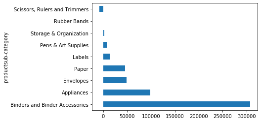

```python
df[df["productcategory"] == "Office Supplies"].groupby("productsub-category")["profit"].sum().sort_values(ascending=False).plot(kind="barh")
```

The most profitable office supplies are binders and accessories, then appliances then envelopes. Scissors, rulers, and trimmers bring negative profit, and rubber bands and storage and organization give little profit

### Overall, what kinds of technology are profitable?

```python
df[df["productcategory"] == "Technology"].groupby("productsub-category")["profit"].sum().sort_values(ascending=False)
```

```
productsub-category
Telephones and Communication    316951.641
Office Machines                 276590.340
Copiers and Fax                 167361.464
Computer Peripherals             94533.780
Name: profit, dtype: float64
```

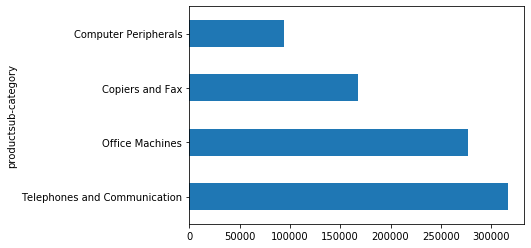

```python
df[df["productcategory"] == "Technology"].groupby("productsub-category")["profit"].sum().sort_values(ascending=False).plot(kind="barh")
```

Telephones and communication products give the most profit, well over 300k. Next is office machines with 270k in profit.

### Is there any relationship (or correlation) between “profits” and “sales”? Show a trend line

```python
df.corr()
```

|  | orderid | orderquantity | sales | discount | profit | unitprice | shippingcost | zipcode | productbasemargin |
| --- | --- | --- | --- | --- | --- | --- | --- | --- | --- |
| orderid | 1.000000 | 0.011461 | -0.006822 | -0.003568 | -0.005849 | -0.003867 | -0.003857 | -0.011369 | -0.024529 |
| orderquantity | 0.011461 | 1.000000 | 0.220413 | -0.010160 | 0.196062 | -0.104341 | -0.012162 | 0.017114 | 0.006781 |
| sales | -0.006822 | 0.220413 | 1.000000 | -0.018951 | 0.577657 | 0.602518 | 0.434261 | -0.011301 | 0.157456 |
| discount | -0.003568 | -0.010160 | -0.018951 | 1.000000 | -0.038563 | 0.001760 | -0.000269 | 0.002057 | 0.005559 |
| profit | -0.005849 | 0.196062 | 0.577657 | -0.038563 | 1.000000 | -0.035542 | -0.018124 | -0.004923 | -0.106292 |
| unitprice | -0.003867 | -0.104341 | 0.602518 | 0.001760 | -0.035542 | 1.000000 | 0.239953 | -0.007564 | 0.058523 |
| shippingcost | -0.003857 | -0.012162 | 0.434261 | -0.000269 | -0.018124 | 0.239953 | 1.000000 | -0.018904 | 0.374660 |
| zipcode | -0.011369 | 0.017114 | -0.011301 | 0.002057 | -0.004923 | -0.007564 | -0.018904 | 1.000000 | 0.006904 |
| productbasemargin | -0.024529 | 0.006781 | 0.157456 | 0.005559 | -0.106292 | 0.058523 | 0.374660 | 0.006904 | 1.000000 |

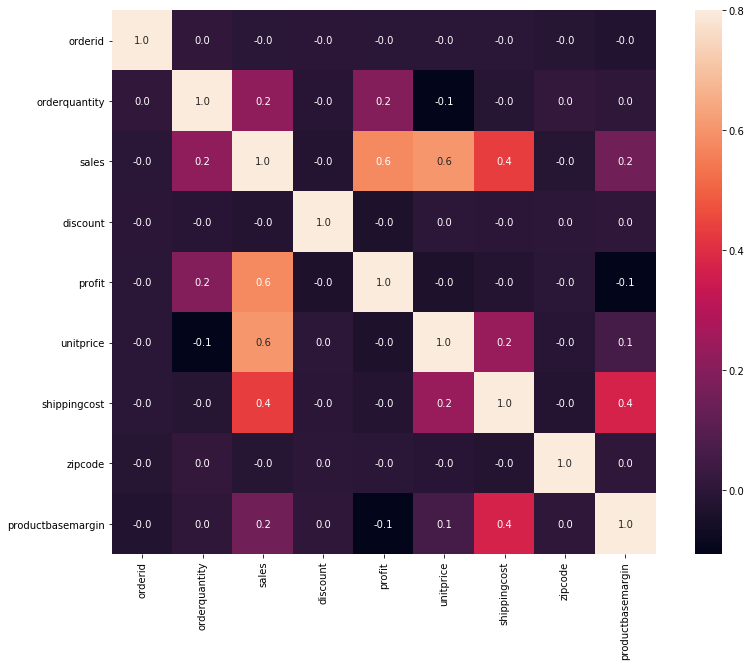

```python
plt.figure(figsize=(14,10))
sns.heatmap(df.corr(), vmax=.8, square=True, annot=True, fmt=".1f")
```

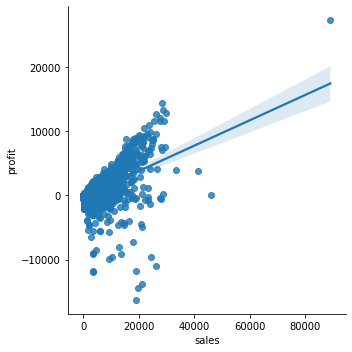

```python
sns.lmplot(x="sales", y="profit", data=df)
```

There is a positive correlation between profit and sales. A correlation test shows a 0.6 correlation between the two

### Overall, which year is least profitable?

- Ignore year 2008 since it has only two months in the data

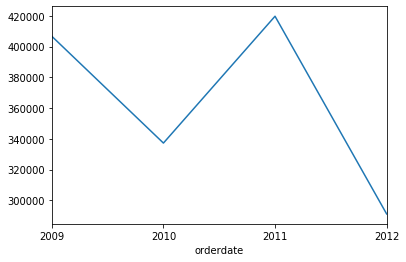

```python
df.resample("Y")["profit"].sum()[1:].plot()
```

The graph shows that the year 2012 was the least profitable year, with about 300k in profit